# Exam 1

## Exam 1

#### Question

1. A farm produces 4 types of fruit: watermelons, mangos, persimmons, and kiwis. The fruits’ masses follow normal distributions, with parameters dependent on the type of fruit.

   | Type of fruit _ | _ Mean mass (g) _ | _ Standard deviation of mass (g) _ |
   | --- | --- | --- |
   | watermelons | 9840 | 570 |
   | mangos | 301 | 48 |
   | persimmons | 142 | 15 |
   | kiwis | 81 | 9 |

   One specimen of each type is weighed. The results are shown below.

   | specimen type _ | _ Mass of specimen (g) |
   | --- | --- |
   | watermelon | 8740 |
   | mango | 262.1 |
   | persimmon | 160.9 |
   | kiwi | 94.23 |

   1. Calculate a $z$ score for the watermelon specimen. (Round to the nearest hundredth.)
   2. What percent of watermelons have less mass than the watermelon specimen?
   3. Calculate a $z$ score for the mango specimen. (Round to the nearest hundredth.)
   4. What percent of mangos have less mass than the mango specimen?
   5. Calculate a $z$ score for the persimmon specimen. (Round to the nearest hundredth.)
   6. What percent of persimmons have less mass than the persimmon specimen?
   7. Calculate a $z$ score for the kiwi specimen. (Round to the nearest hundredth.)
   8. What percent of kiwis have less mass than the kiwi specimen?
   9. The watermelon specimen is most unusually large. / The mango specimen is most unusually large. / The persimmon specimen is most unusually large. / The kiwi specimen is most unusually large.
   10. The watermelon specimen is most unusually small. / The mango specimen is most unusually small. / The persimmon specimen is most unusually small. / The kiwi specimen is most unusually small.
   11. The watermelon specimen is most typically sized. / The mango specimen is most typically sized. / The persimmon specimen is most typically sized. / The kiwi specimen is most typically sized.
   12. The watermelon specimen is most unusually sized. / The mango specimen is most unusually sized. / The persimmon specimen is most unusually sized. / The kiwi specimen is most unusually sized.

#### Solution

   1. We use the formula for calculating the watermelon specimen’s $z$ score.
      $$z = \frac{8740-9840}{570} = -1.93$$
   2. Use the $z$ table to find the percentile rank.
      $$P(Z<-1.93) = 0.0268$$
   3. We use the formula for calculating the mango specimen’s $z$ score.
      $$z = \frac{262.1-301}{48} = -0.81$$
   4. Use the $z$ table to find the percentile rank.
      $$P(Z<-0.81) = 0.209$$
   5. We use the formula for calculating the persimmon specimen’s $z$ score.
      $$z = \frac{160.9-142}{15} = 1.26$$
   6. Use the $z$ table to find the percentile rank.
      $$P(Z<1.26) = 0.8962$$
   7. We use the formula for calculating the kiwi specimen’s $z$ score.
      $$z = \frac{94.23-81}{9} = 1.47$$
   8. Use the $z$ table to find the percentile rank.
      $$P(Z<1.47) = 0.9292$$
   9. We determine the maximum $z$ score is $1.47$, which belongs to the kiwi. / . / . / .
   10. We determine the minimum $z$ score is $-1.93$, which belongs to the watermelon. / . / . / .
   11. We determine the minimum absolute $z$ score is $0.81$, which belongs to the mango. / . / . / .
   12. We determine the maximum absolute $z$ score is $1.93$, which belongs to the watermelon. / . / . / .

#### Question

2. Random variable $Y$ is normally distributed with mean $\mu = 95$ and standard deviation $\sigma = 16$.
   $$Y = \text{N}(95,\,16)$$
   Evaluate $P(Y < 131)$.

#### Solution

   First, draw a sketch. We can label the $Y$ axis by adding integer multiples of 16 to 95. We know to shade toward the left because small values of $Y$ satisfy the condition $Y<131$.

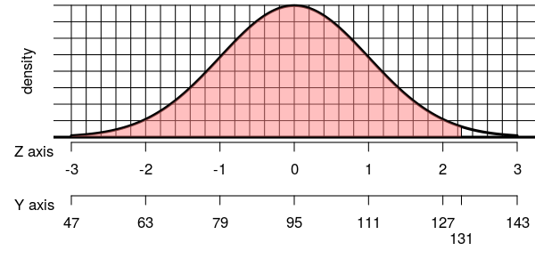

   We are given a specific $y$ value as a boundary. (Remember, for random variables we use uppercase letters, but for specific values we use lowercase.)
   $$y = 131$$
   We calculate the $z$ value of the boundary.
   $$\begin{aligned}
   z &= \frac{y-\mu}{\sigma} \\\\
   &= \frac{131-95}{16} \\\\
   &= 2.25
   \end{aligned}$$

   We have rephrased our problem into a **standard normal** probability problem, because
   $$P(Y<131) ~=~ P(Z<2.25)$$

   So, we just need to evaluate $P(Z<2.25)$. To do this, you just need a $z$-table.

   | $z$ | $P(Z<z)$ |
   | --- | --- |
   | 2.23 | 0.9871 |
   | 2.24 | 0.9875 |
   | **2.25** | **0.9878** |
   | 2.26 | 0.9881 |
   | 2.27 | 0.9884 |

   Thus, we find our answer.
   $$P(Y<131) = 0.9878$$

#### Question

3. Random variable $K$ is normally distributed with mean $\mu = 230$ and standard deviation $\sigma = 20$.
   $$K = \text{N}(230,\,20)$$
   Evaluate $P(K > 240)$.

#### Solution

   First, draw a sketch. We can label the $K$ axis by adding integer multiples of 20 to 230. We know to shade toward the right because large values of $K$ satisfy the condition $K>240$.

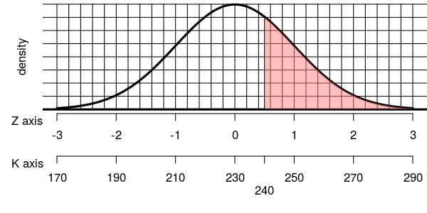

   We are given a specific $k$ value as a boundary. (Remember, for random variables we use uppercase letters, but for specific values we use lowercase.)
   $$k = 240$$
   We calculate the $z$ value of the boundary.
   $$\begin{aligned}
   z &= \frac{k-\mu}{\sigma} \\\\
   &= \frac{240-230}{20} \\\\
   &= 0.5
   \end{aligned}$$

   We have rephrased our problem into a **standard normal** probability problem, because
   $$P(K>240) ~=~ P(Z>0.5)$$

   So, we just need to evaluate $P(Z>0.5)$.

   To do this, you need to remember that right-area events are complementary to left-area events.
   $$P(Z>0.5) ~=~ 1-P(Z<0.5)$$

   You can use a $z$-table.

   | $z$ | $P(Z<z)$ |
   | --- | --- |
   | 0.48 | 0.6844 |
   | 0.49 | 0.6879 |
   | **0.5** | **0.6915** |
   | 0.51 | 0.695 |
   | 0.52 | 0.6985 |

   Thus, we find our answer.
   $$\begin{aligned}
   P(K>240) &= 1-0.6915 \\
   &= 0.3085
   \end{aligned}$$

#### Question

4. Random variable $V$ is normally distributed with mean $\mu = 730$ and standard deviation $\sigma = 200$.
   $$V = \text{N}(730,\,200)$$
   Evaluate $P\left(\big|V-730\big| < 90\right)$. In other words, what is the probability that $V$ is within $\pm90$ units from the mean?

#### Solution

   First, draw a sketch. We can label the $V$ axis by adding integer multiples of 200 to 730. We know to shade the center because values near 730 satisfy the condition $\big|V-730\big| < 90$. We draw the boundaries at $730-90=640$ and $730+90=820$ because those are the solutions to $\big|V-730\big| = 90$. We can also rephrase the probability.

   $$P\left(\big|V-730\big| < 90\right) ~=~ P(640<V<820)$$

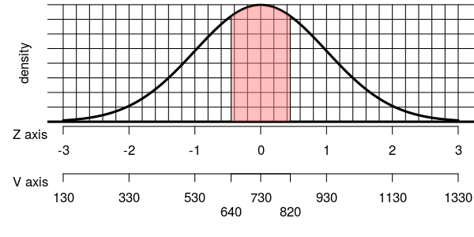

   We calculate the $z$ values of the boundaries. Left boundary:
   $$\begin{aligned}
   z_1 &= \frac{640-730}{200} \\\\
   &= \frac{-90}{200} \\\\
   &= -0.45
   \end{aligned}$$

   Right boundary:

   $$\begin{aligned}
   z_2 &= \frac{820-730}{200} \\\\
   &= \frac{90}{200} \\\\
   &= 0.45
   \end{aligned}$$

   We have rephrased our problem into a **standard normal** probability problem, because

   $$P\left(\big|V-730\big| < 90\right) ~=~ P(640<V<820) ~=~ P(-0.45<Z<0.45) ~=~ P\left(\big|Z\big|<0.45\right)$$

   So, we just need to evaluate $P(|Z|<0.45)$. I will also point out that $\frac{90}{200} = 0.45$. In general, if $X$ is normally distributed, then:
   $$P\left(\big|X-\mu\big|<d\right) ~=~ P\left(\big|Z\big| < \frac{d}{\sigma}\right)$$

   From here we have a formula that lets us use the $z$ table. (We practiced this part before.)
   $$\begin{aligned}
   P(|Z|<0.45) &= 2 \times P(Z<0.45)-1 \\
   &= 2 \times 0.6736-1 \\
   &= 0.3472
   \end{aligned}$$

#### Question

5. Random variable $A$ is normally distributed with mean $\mu = 77$ and standard deviation $\sigma = 20$.
   $$A = \text{N}(77,\,20)$$
   Evaluate $P\left(\big|A-77\big| > 25\right)$. In other words, what is the probability that $A$ is outside $\pm25$ units from the mean?

#### Solution

   First, draw a sketch. We can label the $A$ axis by adding integer multiples of 20 to 77. We know to shade the two tails because values far from 77 satisfy the condition $\big|A-77\big| > 25$. We draw the boundaries at $77-25=52$ and $77+25=102$ because those are the solutions to $\big|A-77\big| = 25$. We can also rephrase the probability.

   $$P\left(\big|A-77\big| > 25\right) ~=~ P\big(A<52 \text{ OR } A>102\big)$$

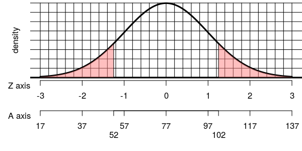

   We calculate the $z$ values of the boundaries. Left boundary:
   $$\begin{aligned}
   z_1 &= \frac{52-77}{20} \\\\
   &= \frac{-25}{20} \\\\
   &= -1.25
   \end{aligned}$$

   Right boundary:

   $$\begin{aligned}
   z_2 &= \frac{102-77}{20} \\\\
   &= \frac{25}{20} \\\\
   &= 1.25
   \end{aligned}$$

   We have rephrased our problem into a **standard normal** probability problem, because

   $$P\left(\big|A-77\big| > 25\right) ~=~ P\left(\big|Z\big|>1.25\right)$$

   So, we just need to evaluate $P(|Z|>1.25)$. I will also point out that $\frac{25}{20} = 1.25$. In general, if $X$ is normally distributed, then:
   $$P\left(\big|X-\mu\big|>d\right) ~=~ P\left(\big|Z\big| > \frac{d}{\sigma}\right)$$

   From here we have a formula that lets us use the $z$ table. (We practiced this part before.)
   $$\begin{aligned}
   P(|Z|>1.25) &= 2- 2 \times P(Z<1.25) \\
   &= 2 - 2 \times 0.8944 \\
   &= 0.2112
   \end{aligned}$$

#### Question

6. Random variable $D$ is normally distributed with mean $\mu = 180$ and standard deviation $\sigma = 50$.
   $$D = \text{N}(180,\,50)$$
   Evaluate $P\left(70 < X < 270\right)$. In other words, what is the probability that $D$ is between $70$ and $270$?

#### Solution

   First, draw a sketch. We can label the $D$ axis by adding integer multiples of 50 to 180. We know to shade the between $70$ and $270$ because those values satisfy the condition $70 < X < 270$.

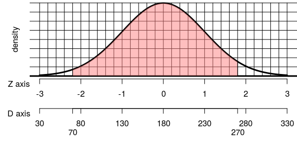

   We calculate the $z$ values of the boundaries. Left boundary:
   $$\begin{aligned}
   z_1 &= \frac{x_1-\mu}{\sigma} \\\\
   &= \frac{70-180}{50} \\\\
   &= -2.2
   \end{aligned}$$

   Right boundary:

   $$\begin{aligned}
   z_2 &= \frac{x_2-\mu}{\sigma} \\\\
   &= \frac{270-180}{50} \\\\
   &= 1.8
   \end{aligned}$$

   We rephrase our problem into a **standard normal** probability problem:

   $$P\left(70 < X < 270\right) ~=~ P(-2.2<Z<1.8)$$

   So, we just need to evaluate $P(-2.2<Z<1.8)$.

   From here we have a formula that lets us use the $z$ table. (We practiced this part before.)
   $$\begin{aligned}
   P(z_1 < Z < z_2) &= P(Z<z_2) - P(Z<z1) \\
   P(-2.2<Z<1.8) &= P(Z<1.8)-P(Z<-2.2)\\
   &= 0.9641-0.0139 \\
   &= 0.9502
   \end{aligned}$$

#### Question

7. Random variable $H$ is normally distributed with mean $\mu = 7.6$ and standard deviation $\sigma = 1.9$.
   $$H = \text{N}(7.6,\,1.9)$$
   Evaluate $h$ such that $P(H<h) = 0.33$. In other words, determine an upper boundary such that a normal spinner with mean 7.6 and standard deviation 1.9 lands on a value less than that boundary 33% of the time.

#### Solution

   First, draw a sketch. We can label the $H$ axis by adding integer multiples of 1.9 to 7.6. We know to shade the left because low values of $H$ satisfy the condition $H<h$ (regardless of the exact value of $h$). We don’t know exactly where to place the boundary, but we know the left area is 0.33.

   It is helpful to know the following approximations:

   | $z$ | $P(Z<z)$ |
   | --- | --- |
   | -3 | 0.001 |
   | -2 | 0.023 |
   | -1 | 0.159 |
   | 0 | 0.5 |
   | 1 | 0.841 |
   | 2 | 0.977 |
   | 3 | 0.999 |

   So, we know the $z$-score is between -1 and 0. Remember, $Z$ and $z$ always refer to the **standard** normal variable.

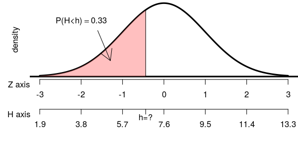

   By using the $z$ table we can determine $z$ more precisely.

   | $z$ | $P(Z<z)$ |
   | --- | --- |
   | -0.46 | 0.3228 |
   | -0.45 | 0.3264 |
   | **-0.44** | **0.33** |
   | **-0.43** | **0.3336** |
   | -0.42 | 0.3372 |
   | -0.45 | 0.3409 |

   Either -0.44 or -0.43 is a good estimation of $z$, and either value will lead you to an acceptable answer. Using other tools, a more accurate value can be found. I will show the work with a more accurate value.
   $$z=-0.4399$$

   We now convert the $z$ score into a $h$ score.
   $$\begin{aligned}
   h &= \mu+z\sigma \\
   &= 7.6+(-0.4399)(1.9) \\
   &= 6.764
   \end{aligned}$$

   We can also visualize this with a spinner.

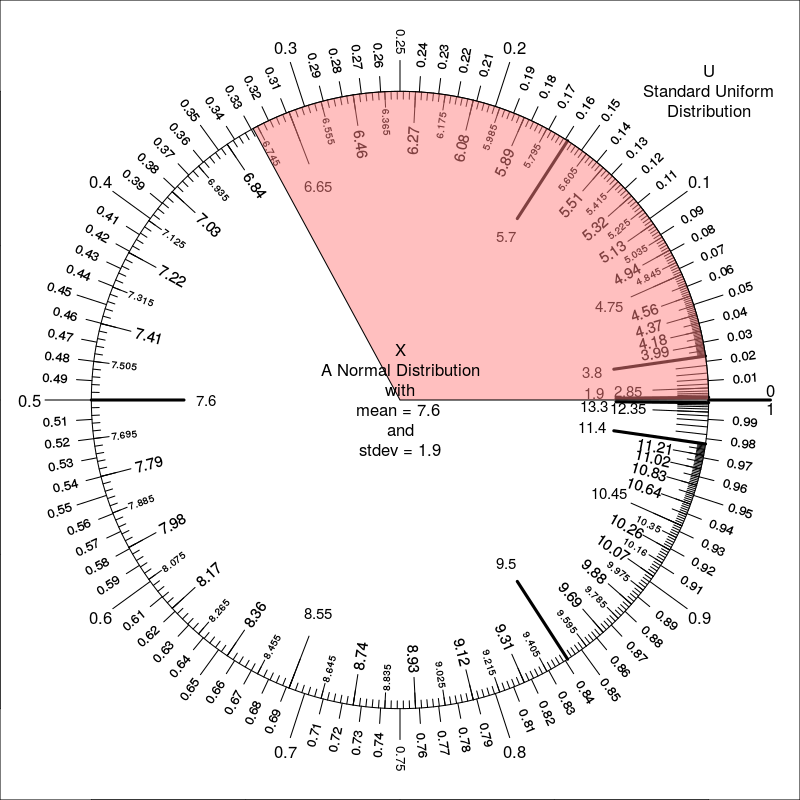

   The tolerance for an acceptable answer was $\pm 0.1$ from 6.764165. So, anything between 6.664165 and 6.864165 was accepted.

#### Question

8. Random variable $R$ is normally distributed with mean $\mu = 180$ and standard deviation $\sigma = 50$.
   $$R = \text{N}(180,\,50)$$
   Evaluate $r$ such that $P(R>r) = 0.83$. In other words, determine an lower boundary such that a normal spinner with mean 180 and standard deviation 50 lands above that boundary 83% of the time.

#### Solution

   First, draw a sketch. We can label the $R$ axis by adding integer multiples of 50 to 180. We know to shade the right because high values of $R$ satisfy the condition $R>r$ (regardless of the exact value of $r$). We don’t know exactly where to place the boundary, but we know the right area is 0.83.

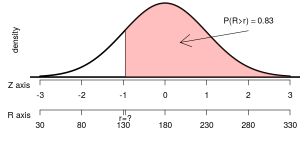

   We know how to find the left area.
   $$\begin{aligned}
   P(R<r) &= 1-P(R>r) \\
   &= 1-0.83 \\
   &= 0.17
   \end{aligned}$$

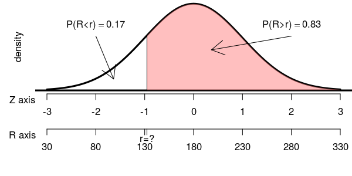

   As an intermediate step, we find $z$ such that $P(Z<z)=0.17$.

   By using the $z$ table we can determine $z$.

   | $z$ | $P(Z<z)$ |
   | --- | --- |
   | -0.98 | 0.1635 |
   | -0.97 | 0.166 |
   | **-0.96** | **0.1685** |
   | **-0.95** | **0.1711** |
   | -0.94 | 0.1736 |
   | -0.97 | 0.1762 |

   Either -0.96 or -0.95 is a good estimation of $z$, and either value will lead you to an acceptable answer. Using other tools, a more accurate value can be found. I will show the work with a more accurate value.
   $$z=-0.9542$$

   We now convert the $z$ score into a $r$ score.
   $$\begin{aligned}
   r &= \mu+z\sigma \\
   &= 180+(-0.9542)(50) \\
   &= 132.3
   \end{aligned}$$

   We can also visualize this with a spinner.

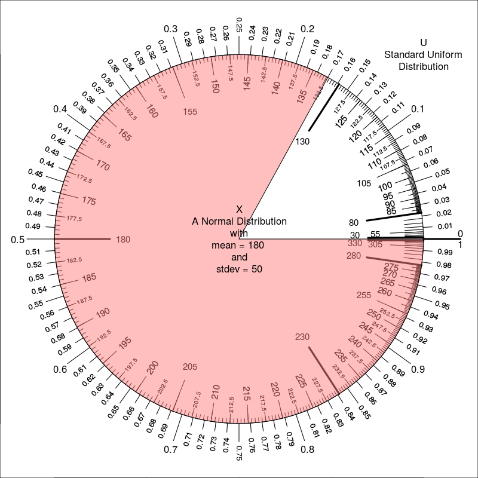

   The tolerance for an acceptable answer was $\pm 10$ from 132.2917373. So, anything between 122.2917373 and 142.2917373 was accepted.

#### Question

9. Random variable $M$ is normally distributed with mean $\mu = 0.98$ and standard deviation $\sigma = 0.2$.
   $$M = \text{N}(0.98,\,0.2)$$
   1. Evaluate $d$ such that $P\left(\big|M-0.98\big|<d\right) = 0.28$. In other words, determine the distance from mean of two boundaries such that this normal spinner lands between those boundaries 28% of the time.
   2. Let $m_1 = 0.98-d$ and $m_2 = 0.98+d$, such that $P\left(m_1 < M < m_2\right) = 0.28$. Evaluate $m_1$.
   3. Using the definitions above, evaluate $m_2$

#### Solution

   First, draw a sketch. We can label the $M$ axis by adding integer multiples of 0.2 to 0.98. We know to shade the the middle because values near 0.98 satisfy the condition $\big|M-0.98\big|<d$ (regardless of the exact value of $d$). We don’t know exactly where to place the boundaries, but we know the central area is 0.28.

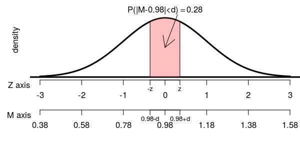

   As an intermediate step, let’s find $z$ such that $P(|Z|<z)=0.28$. First, we need to evaluate $P(Z<z)$.

   You could have also drawn some pictures… we know there is symmetry and all the areas should add to 1.

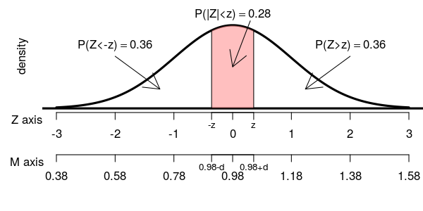

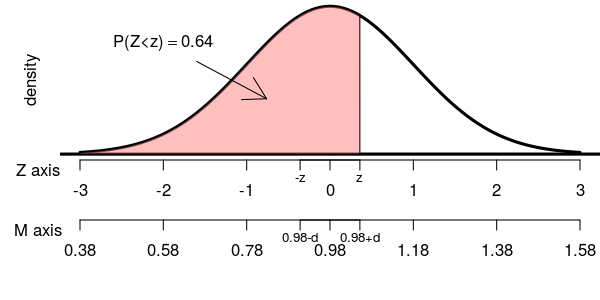

   We find $z$ such that $P(Z<z)=0.64$.

   By using the $z$ table we can determine $z$.

   | $z$ | $P(Z<z)$ |
   | --- | --- |
   | 0.33 | 0.6293 |
   | 0.34 | 0.6331 |
   | **0.35** | **0.6368** |
   | **0.36** | **0.6406** |
   | 0.37 | 0.6443 |
   | 0.34 | 0.648 |

   Either 0.35 or 0.36 is a good estimation of $z$, and either value will lead you to an acceptable answer. Using other tools, a more accurate value can be found. I will show the work with a more accurate value.
   $$z=0.3585$$

   We now convert the $z$ score into a $d$ score.
   $$\begin{aligned}
   d &= z\sigma \\
   &= (0.3585)(0.2) \\
   &= 0.07169
   \end{aligned}$$

   We can also visualize this with a spinner.

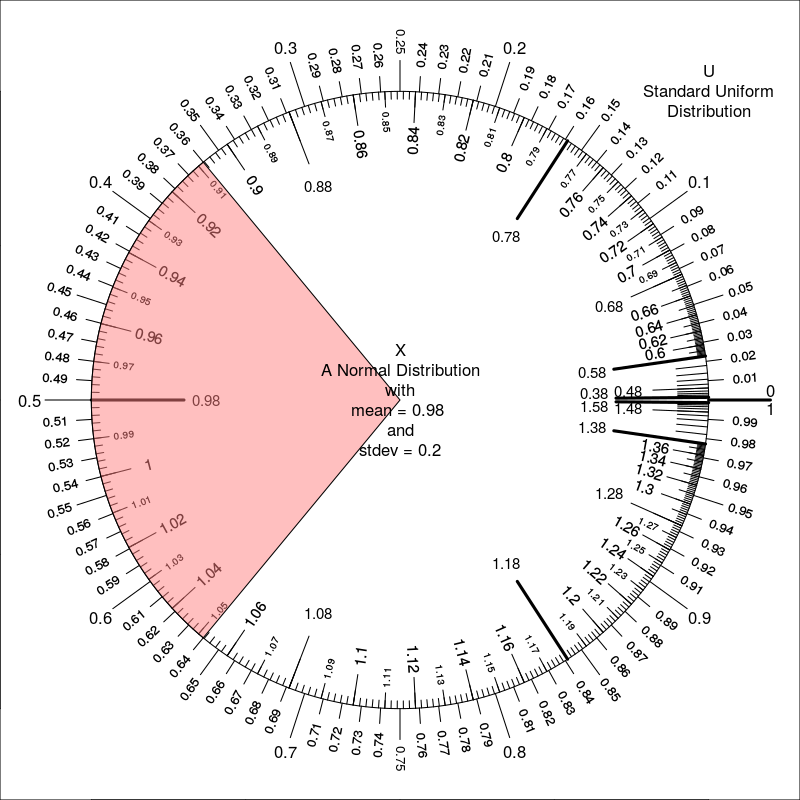

   1. We determined $d=0.07169$
   2. It is easy to find $m_1 = 0.98-0.07169 = 0.90831$
   3. It is easy to find $m_2 = 0.98+0.07169 = 1.05169$

#### Question

10. Random variable $S$ is normally distributed with mean $\mu = 0.83$ and standard deviation $\sigma = 0.25$.
    $$S = \text{N}(0.83,\,0.25)$$
    1. Evaluate $d$ such that $P\left(\big|S-0.83\big|>d\right) = 0.88$. In other words, determine the distance from mean of two boundaries such that this normal spinner lands outside those boundaries 88% of the time.
    2. Let $s_1 = 0.83-d$, such that $P\left(S < s_1\right) = \frac{0.88}{2}$. Evaluate $s_1$.
    3. Let $s_2 = 0.83+d$, such that $P\left(S > s_2\right) = \frac{0.88}{2}$. Evaluate $s_2$.

#### Solution

    First, draw a sketch. We can label the $S$ axis by adding integer multiples of 0.25 to 0.83. We know to shade the the outsides because values far from 0.83 satisfy the condition $\big|S-0.83\big|>d$ (regardless of the exact value of $d$). We don’t know exactly where to place the boundaries, but we know the two-tail area is 0.88.

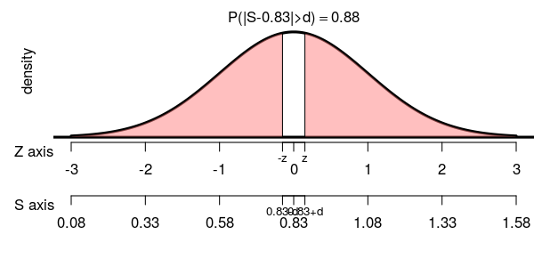

    As an intermediate step, let’s find $z$ such that $P(|Z|>z)=0.88$. First, we need to evaluate $P(Z<z)$.

    You could have also drawn some pictures… we know there is symmetry and all the areas should add to 1.

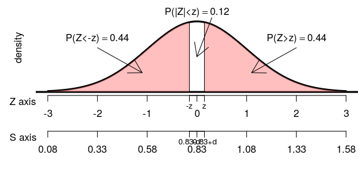

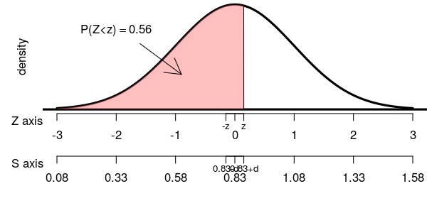

    We find $z$ such that $P(Z<z)=0.56$.

    By using the $z$ table we can determine $z$.

    | $z$ | $P(Z<z)$ |
    | --- | --- |
    | 0.13 | 0.5517 |
    | 0.14 | 0.5557 |
    | **0.15** | **0.5596** |
    | **0.16** | **0.5636** |
    | 0.17 | 0.5675 |
    | 0.14 | 0.5714 |

    Either 0.15 or 0.16 is a good estimation of $z$, and either value will lead you to an acceptable answer. Using other tools, a more accurate value can be found. I will show the work with a more accurate value.
    $$z=0.151$$

    We now convert the $z$ score into a $d$ score.
    $$\begin{aligned}
    d &= z\sigma \\
    &= (0.151)(0.25) \\
    &= 0.03774
    \end{aligned}$$

    We can also visualize this with a spinner.

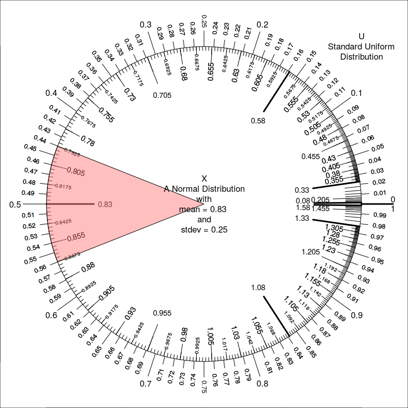

    1. We determined $d=0.03774$
    2. It is easy to find $s_1 = 0.83-0.03774 = 0.79226$
    3. It is easy to find $s_2 = 0.83+0.03774 = 0.86774$